# Homework11

Anusha Ramamurthy

April 19, 2016

1. M&M’s Milk Chocolate Candies were first manufactured in 1940. In Spring 2006, the Mars company claimed that it was mixing M&M’s in the following proportions: Brown Yellow Red Blue Orange Green 0.13 0.14 0.13 0.24 0.20 0.16

To test this claim, I distributed two bags of M&M’s to six students enrolled in Math 352 (Data Analysis) at the College of William & Mary, who observed the following counts:

Brown Yellow Red Blue Orange Green 121 84 118 226 226 123

Do you find the claimed proportions credible in light of these data?

```r
observed = c(121, 84, 118, 226, 226, 123)
N = sum(observed)
expected = c(0.13*N, 0.14*N, 0.13*N, 0.24*N, 0.20*N, 0.16*N)
sum(expected)
```

```
## [1] 898
```

```r
G2 = 2 * sum(observed * log(observed/expected))
1 - pchisq(G2, df=5)
```

```
## [1] 1.141029e-05
```

```r
X2 = sum((observed - expected)^2/expected)
1 - pchisq(X2, df=5)
```

```
## [1] 1.860203e-05
```

- Answer: We observe that the p-value is close to zero. Hence we reject the null hypothesis. However do keep in mind that two bags of MM’s is a fairly small set.
2. Let X(S) = {1, 2, . . . , 9} and consider the probability mass function f(x) = P(X = x) = log10 (1 + 1/x) . In 1881, S. Newcomb noted that this pmf approximates the distribution of the leading digit in the values of a logarithm table. In 1938, F. Benford noted the same phenomenon in a variety of different data sets. The phenomenon is now known as Benford’s law.
1. Verify that f is indeed a pmf.
- The area under the curve f(x) shuld be equal to 1. Thus the sum of f(x) should be equal to one for f(x) to be a valid pmf

```r
x = c(1:9)
fx = log10(1+(1/x))
sum(fx)
```

```
## [1] 1
```

- Hence f(x) is a valid pmf.
2. The following table6 reports the leading digit of the populations of 305 towns on a randomly selected page of a gazeteer. Leading digit 1 2 3 4 5 6 7 8 9 Number of towns 107 55 39 22 13 18 13 23 15

On the basis of these data, is it plausible that the leading digits of town populations follow Benford’s law?

```r
observed = c(107, 55, 39, 22, 13, 18, 13, 23, 15)
N = sum(observed)

expected = fx*N

sum(observed)
```

```
## [1] 305
```

```r
sum(expected)
```

```
## [1] 305
```

```r
G2 = 2 * sum(observed * log(observed/expected))
1 - pchisq(G2, df=8)
```

```
## [1] 0.04919622
```

```r
X2 = sum((observed - expected)^2/expected)
1 - pchisq(X2, df=8)
```

```
## [1] 0.06399094
```

- Here we observe that Likelihood and pearson’s methods give us different values. Pearson’s provides a p-value greater than 0.05, but it is boderline.It doesn’t seem plausible that the leading digits of town populations follow Benford’s law.
3. A study of Hodgkin’s disease classified n = 538 patients by histological type (LP = lymphocyte predominance, NS = nodular sclerosis, MC = mixed cellularity, LD = lymphocyte depletion) and response to treatment (positive, partial, none), resulting in the following 4 × 3 contingency table:9 Positive Partial None LP 74 18 12 NS 68 16 12 MC 154 54 58 LD 18 10 44

Do these data provide evidence that response to treatment for Hodgkin’s disease varies by histological type?

```r
observed = c(74,18,12,68,16,12,154,54,58,18,10,44)
N = sum(observed)
LP = sum(74,18,12)/N
NS = sum(68,16,12)/N
MC = sum(154,54,58)/N
LD = sum(18,10,44)/N
Ps = sum(74,68,154,18)/N
partial = sum(18,16,54,10)/N
none = sum(12,12,58,44)/N

expected = c(LP*Ps*N,LP*partial*N,LP*none*N,NS*Ps*N,NS*partial*N,NS*none*N,MC*Ps*N,MC*partial*N,MC*none*N,LD*Ps*N,LD*partial*N,LD*none*N)


sum(observed)
```

```
## [1] 538
```

```r
sum(expected)
```

```
## [1] 538
```

```r
# Likelihood ratio
G2 = 2 * sum(observed * log(observed/expected))
1 - pchisq(G2, df=6)
```

```
## [1] 9.139356e-13
```

```r
# Pearsons X^2
X2 = sum((observed - expected)^2/expected)
1 - pchisq(X2, df=6)
```

```
## [1] 2.520206e-14
```

- The p-values are very small. So I would say that I would reject the null hypothesis of Independence and conclude that data is inconsistent with the null hypotheisis
4. Is anger associated with heart disease? Williams et al. (2000) gave a sample of 8474 people with no heart disease and normal blood pressure a test to classify their anger as low, moderate, or high. The researchers then tracked the subjects for four years, recording which of them developed heart disease. The results:
1. Of 3110 people with low anger, 53 got heart disease.
2. Of 4731 people with moderate anger, 110 got heart disease.
3. Of 633 people with high anger, 27 got heart disease.
1. Perform a chi-squared test, giving a test statistic, P-value, and conclusion.

```r
observed = c (53,(3110-53),110,(4731-110),27,(633-27))
N = sum(observed)
LA = 3110/N
MA = 4731/N
HA = 633/N

NHD = sum(3057,4621,606)/N
HD = sum(53,110,27)/N

expected = c(LA*HD*N,LA*NHD*N, MA*HD*N, MA*NHD*N,HA*HD*N,HA*NHD*N)

sum(observed)
```

```
## [1] 8474
```

```r
sum(expected)
```

```
## [1] 8474
```

```r
data.frame(observed, round(expected, 1))
```

```
##   observed round.expected..1.
## 1       53               69.7
## 2     3057             3040.3
## 3      110              106.1
## 4     4621             4624.9
## 5       27               14.2
## 6      606              618.8
```

```r
G2 = 2 * sum(observed * log(observed/expected))
G2
```

```
## [1] 13.99914
```

```r
1 - pchisq(G2, df=2)
```

```
## [1] 0.0009122731
```

```r
X2 = sum((observed - expected)^2/expected)
X2
```

```
## [1] 16.07676
```

```r
1 - pchisq(X2, df=2)
```

```
## [1] 0.0003228312
```

- The p-values are very small. Our null hypothesis is that anger and heart disease are independent. The test shows that our data is inconsistent with our null hypothesis.
2. Does this analysis alone prove that anger affects the chance of getting heart disease? Explain why or why not.
- No. The test alone is not a good proof that anger affects the chances of getting heart diseases. We have no understanding of how the samples were taken, how they were categorized into different anger groups. It may be that certain patients are genetically prone to heart diseases, or any other such conditions that are not explained in this example.
5. In class we found that the number of goals scored in games of the 2000-01 English Premier League soccer season could be adequately modeled using a Poisson distribution. Does the same hold for the 2014-15 season?

Data for this season can be readily found on the internet as a .csv file, a common format for spreadsheet data. You can read it into R using read.csv(): EPL201415 = read.csv(“http://www.football-data.co.uk/mmz4281/1415/E0.csv”)

```r
EPL201415 = read.csv("http://www.football-data.co.uk/mmz4281/1415/E0.csv")
```

1. Home team goals?

```r
summary(EPL201415$FTHG)
```

```
##    Min. 1st Qu.  Median    Mean 3rd Qu.    Max.
##   0.000   1.000   1.000   1.474   2.000   8.000
```

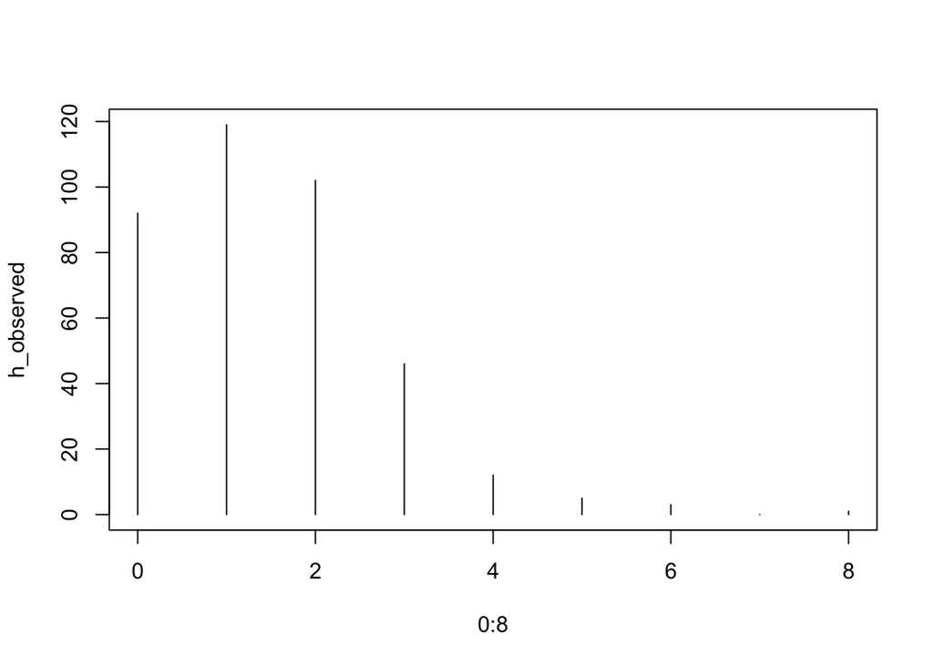

```r
h_observed = c(sum(EPL201415$FTHG == 0),sum(EPL201415$FTHG == 1),sum(EPL201415$FTHG == 2),sum(EPL201415$FTHG == 3),sum(EPL201415$FTHG == 4),sum(EPL201415$FTHG == 5),sum(EPL201415$FTHG == 6),sum(EPL201415$FTHG == 7),sum(EPL201415$FTHG == 8))

plot(0:8, h_observed, type="h")
```

```r
h_games = sum(h_observed)
h_goals = sum((0:8)*h_observed)
h_ave = h_goals/h_games

expected = h_games * dpois(0:20,h_ave)
data.frame(h_goals=0:20, expected=round(expected, 1))
```

```
##    h_goals expected
## 1        0     87.1
## 2        1    128.3
## 3        2     94.5
## 4        3     46.4
## 5        4     17.1
## 6        5      5.0
## 7        6      1.2
## 8        7      0.3
## 9        8      0.0
## 10       9      0.0
## 11      10      0.0
## 12      11      0.0
## 13      12      0.0
## 14      13      0.0
## 15      14      0.0
## 16      15      0.0
## 17      16      0.0
## 18      17      0.0
## 19      18      0.0
## 20      19      0.0
## 21      20      0.0
```

```r
h_expected = rep(0, 6)
h_expected[1:5] = h_games * dpois(0:4, h_ave)
h_expected[6] = h_games * (1 - ppois(4, h_ave))

sum(h_expected)
```

```
## [1] 380
```

```r
h_observed[6] = sum(h_observed[6:9])
h_observed_n = h_observed[1:6]
h_observed[7:9] = 0


sum(h_observed_n)
```

```
## [1] 380
```

```r
X2 = sum((h_observed_n - h_expected)^2/h_expected)
1 - pchisq(X2, df=6)
```

```
## [1] 0.6838186
```

```r
i = (h_observed_n * log(h_observed_n/h_expected))
#i[which(is.nan(i))] = 0
G2 = 2 * sum(i)
1 - pchisq(G2, df=6)
```

```
## [1] 0.6721833
```

2. Away team goals?

```r
summary(EPL201415$FTAG)
```

```
##    Min. 1st Qu.  Median    Mean 3rd Qu.    Max.
##   0.000   0.000   1.000   1.092   2.000   6.000
```

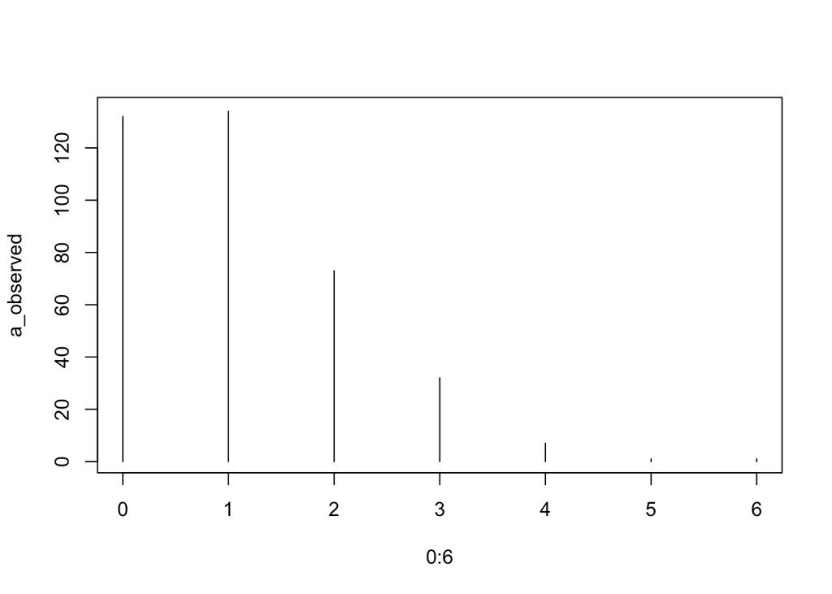

```r
a_observed = c(sum(EPL201415$FTAG == 0),sum(EPL201415$FTAG == 1),sum(EPL201415$FTAG == 2),sum(EPL201415$FTAG == 3),sum(EPL201415$FTAG == 4),sum(EPL201415$FTAG == 5),sum(EPL201415$FTAG == 6))

plot(0:6, a_observed, type="h")
```

```r
a_games = sum(a_observed)
a_goals = sum((0:6)*a_observed)
a_ave = a_goals/a_games

expected = a_games * dpois(0:20, a_ave)
data.frame(a_goals=0:20, expected=round(expected, 1))
```

```
##    a_goals expected
## 1        0    127.5
## 2        1    139.2
## 3        2     76.0
## 4        3     27.7
## 5        4      7.6
## 6        5      1.7
## 7        6      0.3
## 8        7      0.0
## 9        8      0.0
## 10       9      0.0
## 11      10      0.0
## 12      11      0.0
## 13      12      0.0
## 14      13      0.0
## 15      14      0.0
## 16      15      0.0
## 17      16      0.0
## 18      17      0.0
## 19      18      0.0
## 20      19      0.0
## 21      20      0.0
```

```r
a_expected = rep(0, 5)
a_expected[1:4] = a_games * dpois(0:3, a_ave)
a_expected[5] = a_games * (1 - ppois(3, a_ave))

a_observed[5] = sum(a_observed[5:7])
a_observed[6:7] = 0
a_observed_n = a_observed[1:5]


sum(a_observed_n)
```

```
## [1] 380
```

```r
sum(a_expected)
```

```
## [1] 380
```

```r
sum(a_observed)
```

```
## [1] 380
```

```r
X2 = sum((a_observed_n - a_expected)^2/a_expected)
1 - pchisq(X2, df=4)
```

```
## [1] 0.880562
```

```r
i = (a_observed_n * log(a_observed_n/a_expected))
#i[which(is.nan(i))] = 0
G2 = 2 * sum(i)
1 - pchisq(G2, df=4)
```

```
## [1] 0.8853937
```

3. Total goals (home plus away)?

```r
all_goals = c(EPL201415$FTHG,EPL201415$FTAG)
summary(all_goals)
```

```
##    Min. 1st Qu.  Median    Mean 3rd Qu.    Max.
##   0.000   0.000   1.000   1.283   2.000   8.000
```

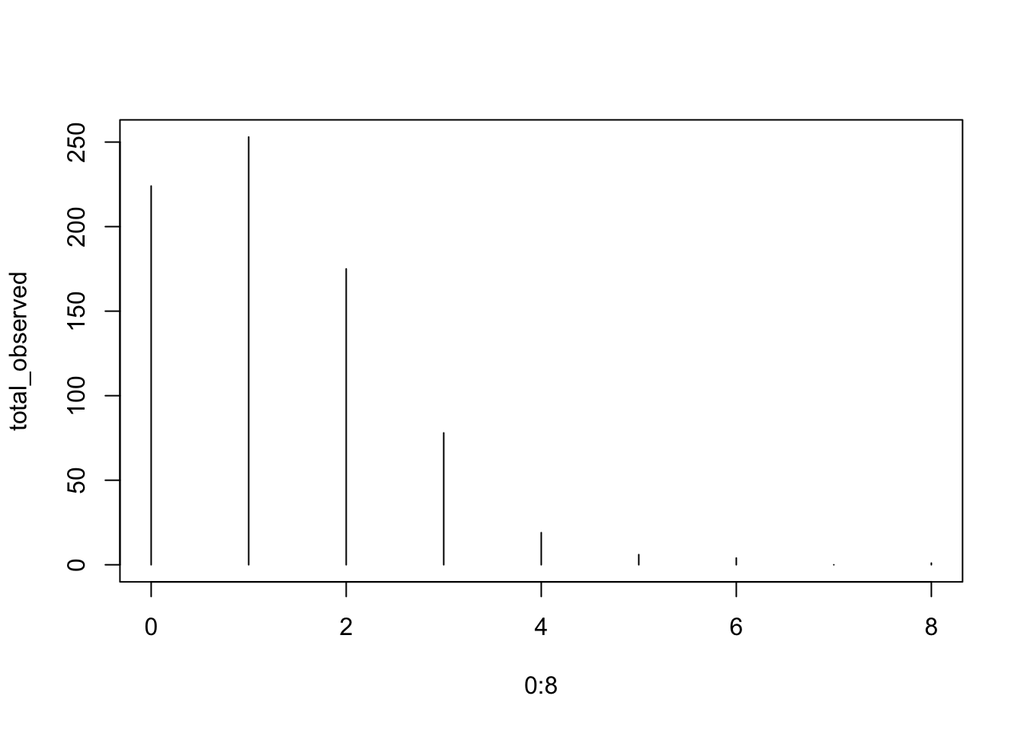

```r
total_observed = c(sum(all_goals == 0),sum(all_goals == 1),sum(all_goals == 2),sum(all_goals == 3),sum(all_goals == 4),sum(all_goals == 5),sum(all_goals == 6),sum(all_goals == 7),sum(all_goals == 8))


plot(0:8, total_observed, type="h")
```

```r
total_games = sum(total_observed)
total_goals = sum((0:8)*total_observed)
total_ave = total_goals/total_games

expected = total_games * dpois(0:8, total_ave)
data.frame(total_goals=0:8, expected=round(expected, 1))
```

```
##   total_goals expected
## 1           0    210.7
## 2           1    270.3
## 3           2    173.4
## 4           3     74.1
## 5           4     23.8
## 6           5      6.1
## 7           6      1.3
## 8           7      0.2
## 9           8      0.0
```

```r
total_expected = rep(0, 6)
total_expected[1:5] = total_games * dpois(0:4, total_ave)
total_expected[6] = total_games * (1 - ppois(4, total_ave))

total_observed[6] = total_observed[6]+total_observed[7]+total_observed[8]+total_observed[9]
total_observed[7]=0
total_observed[8]=0
total_observed[9]=0
total_observed_n = total_observed[1:6]

sum(total_observed_n)
```

```
## [1] 760
```

```r
sum(total_expected)
```

```
## [1] 760
```

```r
sum(total_observed)
```

```
## [1] 760
```

```r
X2 = sum((total_observed_n - total_expected)^2/total_expected)
1 - pchisq(X2, df=6)
```

```
## [1] 0.6028429
```

```r
i = (total_observed_n * log(total_observed_n/total_expected))
#i[which(is.nan(i))] = 0
G2 = 2 * sum(i)
1 - pchisq(G2, df=6)
```

```
## [1] 0.6153442
```

- The p-values for home goals, away goals and home+away goals all have values greater than 0.05. Thus the data is consistent with the null hypothesis and appears to be Poisson distributed.
6. Game Challenge

[figure not shown]